# SRNM_Modeling-Course

#### **1.2.d.One-way ANOVA (Parametric)**

Used to test if the mean yield differs between varieties (same logic as two-sample t-test but framed as a linear model).

```r
anova_model <- aov(yield ~ variety, data = data)
summary(anova_model)
```

```
##             Df Sum Sq Mean Sq F value Pr(>F)
## variety      1  135.9  135.85    5.11  0.034 *
## Residuals   22  584.9   26.58
## ---
## Signif. codes:  0 '***' 0.001 '**' 0.01 '*' 0.05 '.' 0.1 ' ' 1
```

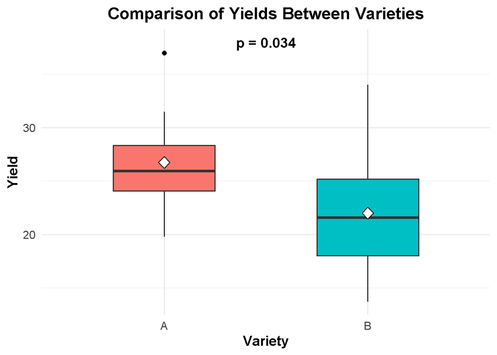

```r
# t-test for p-value
t_res <- t.test(yield ~ variety, data = data, var.equal = TRUE)
library(ggplot2)
p <- ggplot(data, aes(x = variety, y = yield, fill = variety)) +
  geom_boxplot(width = 0.5, outlier.color = "black", outlier.shape = 16) +
  stat_summary(fun = mean, geom = "point", shape = 23, size = 4, fill = "white") +
  labs(title = "Comparison of Yields Between Varieties",
       x = "Variety",
       y = "Yield") +
  theme_minimal(base_size = 14) +
  theme(
    plot.title = element_text(hjust = 0.5, face = "bold"),
    axis.title = element_text(face = "bold"),
    legend.position = "none"
  ) +
  annotate("text", x = 1.5, y = max(data$yield) + 1,
           label = paste0("p = ", signif(t_res$p.value, 3)),
           size = 5, fontface = "bold")

# Show the plot
print(p)
```

**Overall Interpretation**

All three tests — t-test, Wilcoxon, and ANOVA — give p < 0.05. So you can confidently conclude that Variety A has a significantly higher yield than Variety B.

#### **Paired t-test**

To run a paired t-test, just add paired= TRUE to the basic t.test() function

```r
t.test(Variety_A, Variety_B, paired = TRUE) #significant difference between paired yields.
```

```
##
##  Paired t-test
##
## data:  Variety_A and Variety_B
## t = 4.2412, df = 11, p-value = 0.001386
## alternative hypothesis: true mean difference is not equal to 0
## 95 percent confidence interval:
##  2.289003 7.227664
## sample estimates:
## mean difference
##        4.758333
```

####**Paired Wilcoxon signed-rank test (non-parametric)**

```r
wilcox.test(Variety_A, Variety_B, paired = TRUE) #significant difference in median yield between the paired groups.
```

```
##
##  Wilcoxon signed rank exact test
##
## data:  Variety_A and Variety_B
## V = 78, p-value = 0.0004883
## alternative hypothesis: true location shift is not equal to 0
```

### **1.2.d.Part V: Analysis of variance**

ANOVA is used to determine differences between several groups or treatments. The simplest is single factor — one-way ANOVA. Example: Designed Experiment Sexual activity and lifespan (longevity) of male fruit flies Sexual activity was manipulated by supplying individual males with one or eight receptive virgin females per day. The longevity of these males was compared with that of two control types. The first control consisted of two sets of individual males kept with one or eight newly inseminated females. Newly inseminated females will not usually remate for at two days, and thus served as a control for any effect of competition with the male for food or space. The second control was a set of individual males kept with no females. There were 25 males in each of the five groups, which were treated identically in number of anaesthetizations (using C02) and provision of fresh food medium. So there are 5 sexual activity groups (thus the treatments) and the response is longevity (lifespan in days). First go to excel and save the file ‘Fruitfly.xls’ as a csv file. Read these data in R

```r
fly <- read.csv2("./Modeling_Data/fruitfly.csv") #read the data into a table
head(fly) # show the data
```

```
##   group partners type longevity
## 1     1        0    9        40
## 2     1        0    9        37
## 3     1        0    9        44
## 4     1        0    9        47
## 5     1        0    9        47
## 6     1        0    9        47
```

```r
#The column 'group' is numeric and has to be converted into a factor for analysis. (Very important to ensure that qualitative variables are not used as numeric values)
```

```r
fly$group<- as.factor(fly$group)
#We can first verify the homoskedasticity (ie homogeneity of variances). R provides two tests: the Bartlett's test, and the Fligner-Killeen test.
str(fly)
```

```
## 'data.frame':    125 obs. of  4 variables:
##  $ group    : Factor w/ 5 levels "1","2","3","4",..: 1 1 1 1 1 1 1 1 1 1 ...
##  $ partners : int  0 0 0 0 0 0 0 0 0 0 ...
##  $ type     : int  9 9 9 9 9 9 9 9 9 9 ...
##  $ longevity: int  40 37 44 47 47 47 68 47 54 61 ...
```

```r
bartlett.test(fly$longevity, fly$group) #There is evidence that the variances are homogeneous
```

```
##
##  Bartlett test of homogeneity of variances
##
## data:  fly$longevity and fly$group
## Bartlett's K-squared = 2.4196, df = 4, p-value = 0.6591
```

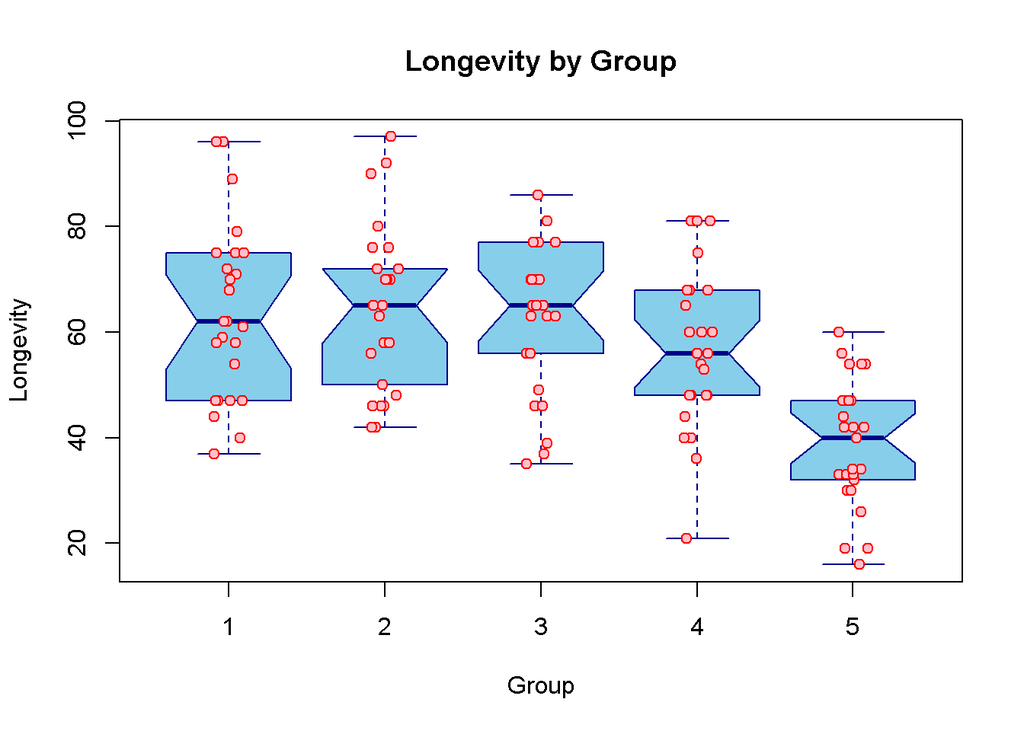

```r
# Basic boxplot
boxplot(longevity ~ group, data = fly,
        main = "Longevity by Group",
        xlab = "Group",
        ylab = "Longevity",
        col = "skyblue",
        border = "darkblue",
        notch = TRUE)

# Optional: add points
stripchart(longevity ~ group, data = fly,
           vertical = TRUE, method = "jitter",
           pch = 21, col = "red", bg = "pink", add = TRUE)
```

```r
anova_model <- aov(longevity ~ group, data = fly)
summary(anova_model)
```

```
##              Df Sum Sq Mean Sq F value   Pr(>F)
## group         4  11939  2984.8   13.61 3.52e-09 ***
## Residuals   120  26314   219.3
## ---
## Signif. codes:  0 '***' 0.001 '**' 0.01 '*' 0.05 '.' 0.1 ' ' 1
```

**Conclusion**: There is a significant difference in mean longevity among the 5 groups.

Can we spot out the pairs of treatments that are different?

We can do several multiple comparison procedure in R namely Tukey’s HSD (Honest significant difference), Student Neuman Keuls (SNK), Least significant difference (LSD), Duncan’s Multiple Range Test (DMRT) etc. However, we need the agricolae package to implement these procedures.

```r
#Install agricolae package and load it in R.
tukey_res <- TukeyHSD(anova_model)
tukey_res
```

```
##   Tukey multiple comparisons of means
##     95% family-wise confidence level
##
## Fit: aov(formula = longevity ~ group, data = fly)
##
## $group
##       diff       lwr        upr     p adj
## 2-1   1.24 -10.36047  12.840468 0.9983034
## 3-1  -0.20 -11.80047  11.400468 0.9999988
## 4-1  -6.80 -18.40047   4.800468 0.4854206
## 5-1 -24.84 -36.44047 -13.239532 0.0000003
## 3-2  -1.44 -13.04047  10.160468 0.9969591
## 4-2  -8.04 -19.64047   3.560468 0.3126549
## 5-2 -26.08 -37.68047 -14.479532 0.0000001
## 4-3  -6.60 -18.20047   5.000468 0.5157692
## 5-3 -24.64 -36.24047 -13.039532 0.0000004
## 5-4 -18.04 -29.64047  -6.439532 0.0003240
```

4️⃣ Explanation

pair column tells you which groups differ.

diff tells you the mean difference between the groups.

p adj tells you statistical significance (Tukey-adjusted).

```r
# Convert to a data frame
tukey_df <- as.data.frame(tukey_res$group)

# Add row names as a column to identify the pairs
tukey_df$pair <- rownames(tukey_res$group)

# Filter for significant differences (p < 0.05)
significant_pairs <- tukey_df[tukey_df$`p adj` < 0.05, ]

significant_pairs
```

```
##       diff       lwr        upr        p adj pair
## 5-1 -24.84 -36.44047 -13.239532 2.958395e-07  5-1
## 5-2 -26.08 -37.68047 -14.479532 7.232306e-08  5-2
## 5-3 -24.64 -36.24047 -13.039532 3.701044e-07  5-3
## 5-4 -18.04 -29.64047  -6.439532 3.240300e-04  5-4
```